# Oxygen Delivery Compliance Trend Analysis

Eric A. Tesdahl, Ph.D., PSTAT

2023-07-10

## Session Info

```r
knitr::opts_chunk$set(echo = TRUE)

#see about a time trend for do2i information
library(data.table);library(lubridate);library(ggplot2)
library(sjPlot)
minDate <- as.POSIXct("2022-06-01")
maxDate <- as.POSIXct("2022-12-31")
```

## Definitions

- DO2i - measure of delivery of oxygen mL/min/m^2
- DO2i272 - whether or not a particular DO2i reading (one of multiple in a case) was above 272 and thus compliant
- AUC632_DO2i272 - total “area under the curve” for a case, using DO2i of 272 as cutoff for starting to measure oxygen debt
- COR_DO2_TS.csv - data set containing individual DO2i readings for cases under analysis
- COR_DO2.csv - data set containing calculated AUC_DO2i272 readings, one per case. This is the total AUC for each case when using 272ml/min/m^2 as the cutoff for beginning to accululate area under the curve.

## Read and Prep Data

```r
#read in data set. all individual do2i readings for 5,325
do2Reads <- fread("COR_DO2_TS.csv")
do2Reads$event_datetime <- as.POSIXct(do2Reads$event_datetime,
                                    format = "%m/%d/%Y %I:%M:%S %p")
do2Reads$week <- lubridate::week(do2Reads$event_datetime)
do2Reads <- do2Reads[!is.na(delivery_oxygen) & event_datetime >= minDate &
                   event_datetime <= maxDate]
do2Reads$isCompliant272 <- ifelse(do2Reads$delivery_oxygen >= 272, 1, 0)

# do2Reads[, week := (week - (min(week)))+1]

#read in AUC272 data set. all AUC272 readings for 5,325
aucData <- fread("COR_DO2.csv")

#get case performed on dates from do2 data
do2Reads$date <- as.Date(do2Reads$event_datetime)
mydates <- unique(do2Reads[, c("CASE_ID_TS", "date")])
aucData <- merge(aucData, mydates, by.x = "CASE_ID", by.y ="CASE_ID_TS")
aucData$week <- lubridate::week(aucData$date)

aucData <- aucData[!is.na(DO2_UNDER_THRES)]

aucData[, isCompliant632 := ifelse(DO2_UNDER_THRES <= 632, 1, 0)]
```

## Check for trend in readings per case

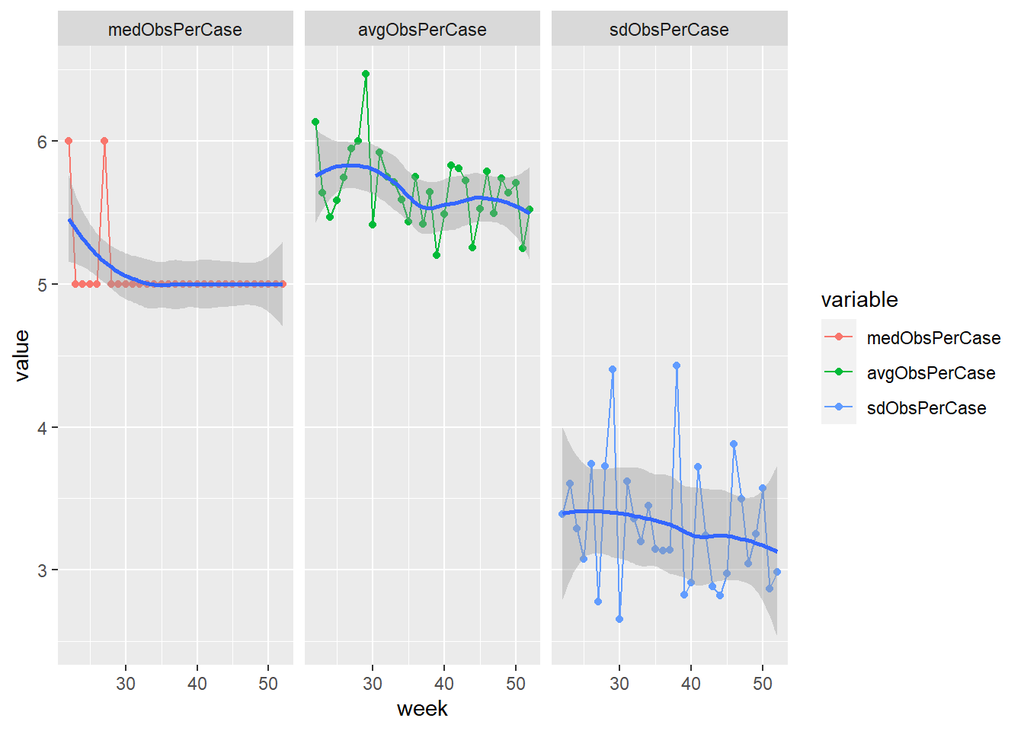

```r
numCases <- length(unique(do2Reads$CASE_ID_TS))

avgReadingsPerCase <- nrow(do2Reads)/numCases

mdByCase <- do2Reads[, .(totObservations = .N), by = .(CASE_ID_TS, week)]

meanNumReadings <- mean(mdByCase$totObservations)
medianNumReadings <- median(mdByCase$totObservations)
sdNumReadings <- sd(mdByCase$totObservations)

mdByCaseByWeek <- mdByCase[, .(medObsPerCase = median(totObservations),
                               avgObsPerCase = mean(totObservations),
                               sdObsPerCase = sd(totObservations)), by = .(week)]

mdByCaseByWeek_m <- melt(mdByCaseByWeek, id.vars = "week")

readsPerCasePlot <- ggplot(data = mdByCaseByWeek_m, aes(x= week, y= value)) +
  geom_line(aes(group = variable, color = variable)) +
  geom_point(aes(color = variable)) +
  facet_wrap(facets = "variable") +
  geom_smooth()
readsPerCasePlot
```

## DO2i272 reading compliance by weeks

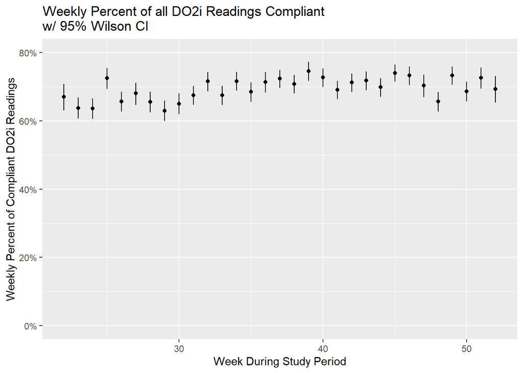

```r
compliantByWeek <- do2Reads[,.(totCases = .N, totCompliant = sum(isCompliant272)),
                          by = .(week)]
compliantByWeek <- cbind(compliantByWeek,
                         Hmisc::binconf(n=compliantByWeek$totCases,
                                        x = compliantByWeek$totCompliant,
                                        return.df = TRUE))
compliantByWeek <- compliantByWeek[order(week)]

p1compByWeek <- ggplot(data = compliantByWeek, aes(x = week, y = PointEst)) +
  geom_point() +
  geom_errorbar(width = 0, aes(ymax = Upper, ymin = Lower)) +
  scale_y_continuous(labels = scales::percent, limits = c(0,.8))  +
  ylab("Weekly Percent of Compliant DO2i Readings") +
  xlab("Week During Study Period") +
  ggtitle("Weekly Percent of all DO2i Readings Compliant\nw/ 95% Wilson CI")
p1compByWeek
```

There appears to be an upward trend in compliance.

### Model probability of DO2i272 reading compliance by week

Check for a linear trend in the probability of DO2i272 reading compliance by estimating a logistic regression model with count of week in study period as a predictor. A significant and positive regression coefficient for week would indicate a statistically relaible postive linear trend in log-odds of DO2i272 reading compliance.

```r
m1 <- glm(data = do2Reads, formula = isCompliant272 ~ week, family = "binomial")
summary(m1)
```

```
##
## Call:
## glm(formula = isCompliant272 ~ week, family = "binomial", data = do2Reads)
##
## Deviance Residuals:
##     Min       1Q   Median       3Q      Max
## -1.6087  -1.4943   0.8287   0.8648   0.9095
##
## Coefficients:
##             Estimate Std. Error z value Pr(>|z|)
## (Intercept) 0.445684   0.055487   8.032 9.57e-16 ***
## week        0.010150   0.001468   6.915 4.69e-12 ***
## ---
## Signif. codes:  0 '***' 0.001 '**' 0.01 '*' 0.05 '.' 0.1 ' ' 1
##
## (Dispersion parameter for binomial family taken to be 1)
##
##     Null deviance: 37055  on 30100  degrees of freedom
## Residual deviance: 37007  on 30099  degrees of freedom
## AIC: 37011
##
## Number of Fisher Scoring iterations: 4
```

```r
mp1 <- plot_model(m1, type = "pred", terms = "week")
```

```
## Data were 'prettified'. Consider using `terms="week [all]"` to get
##   smooth plots.
```

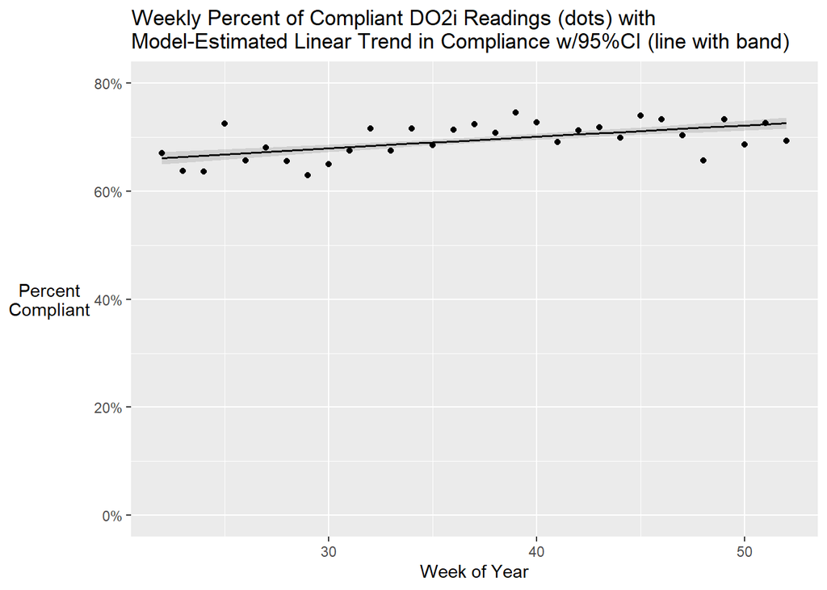

```r
mp1 +
  geom_point(data  = compliantByWeek, aes(x=week, y = PointEst))   +
  scale_y_continuous(labels = scales::percent, limits = c(0,.8))  +
  scale_x_continuous(breaks = c(0,10,20,30,40,50))  +
  ggtitle("Weekly Percent of Compliant DO2i Readings (dots) with\nModel-Estimated Linear Trend in Compliance w/95%CI (line with band)") +
  xlab("Week of Year") +
  ylab("Percent\nCompliant") +
  theme(axis.title.y = element_text(angle = 0, vjust = .5))
```

## AUC632_DO2i272 case compliance by weeks

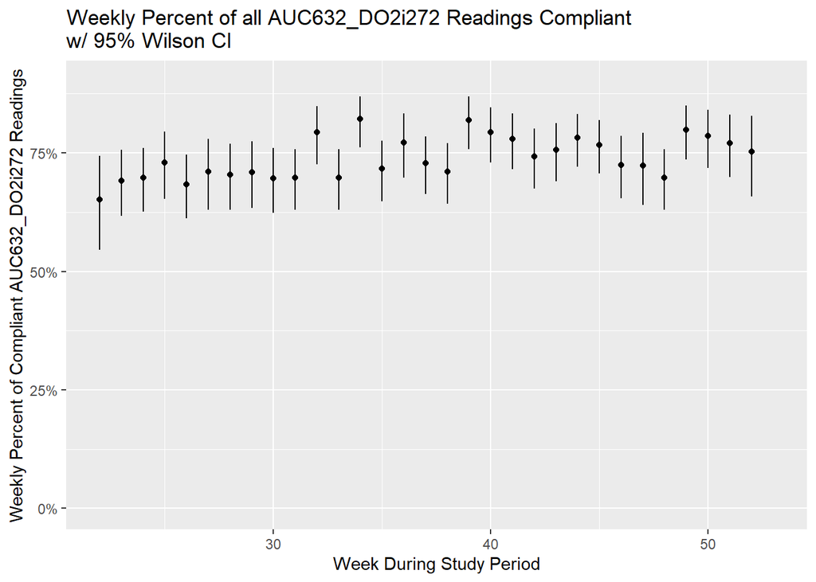

```r
compliantByWeek <- aucData[,.(totCases = .N, totCompliant = sum(isCompliant632)),
                          by = .(week)]
compliantByWeek <- cbind(compliantByWeek,
                         Hmisc::binconf(n=compliantByWeek$totCases,
                                        x = compliantByWeek$totCompliant,
                                        return.df = TRUE))
compliantByWeek <- compliantByWeek[order(week)]

p2compByWeek <- ggplot(data = compliantByWeek, aes(x = week, y = PointEst)) +
  geom_point() +
  geom_errorbar(width = 0, aes(ymax = Upper, ymin = Lower)) +
  scale_y_continuous(labels = scales::percent, limits = c(0,.9))  +
  ylab("Weekly Percent of Compliant AUC632_DO2i272 Readings") +
  xlab("Week During Study Period") +
  ggtitle("Weekly Percent of all AUC632_DO2i272 Readings Compliant\nw/ 95% Wilson CI")
p2compByWeek
```

### Model probability of AUC632_DO2i272 case compliance by week

Check for a linear trend in the probability of AUC632_DO2i272 case compliance by estimating a logistic regression model with count of week in study period as a predictor. A significant and positive regression coefficient for week would indicate a statistically relaible postive linear trend in log-odds of AUC632_DO2i272 case compliance.

```r
m2 <- glm(data = aucData, formula = isCompliant632 ~ week, family = "binomial")
summary(m2)
```

```
##
## Call:
## glm(formula = isCompliant632 ~ week, family = "binomial", data = aucData)
##
## Deviance Residuals:
##     Min       1Q   Median       3Q      Max
## -1.7386  -1.5554   0.7463   0.7930   0.8467
##
## Coefficients:
##             Estimate Std. Error z value Pr(>|z|)
## (Intercept)  0.53276    0.13925   3.826 0.000130 ***
## week         0.01403    0.00369   3.801 0.000144 ***
## ---
## Signif. codes:  0 '***' 0.001 '**' 0.01 '*' 0.05 '.' 0.1 ' ' 1
##
## (Dispersion parameter for binomial family taken to be 1)
##
##     Null deviance: 6052.8  on 5291  degrees of freedom
## Residual deviance: 6038.3  on 5290  degrees of freedom
## AIC: 6042.3
##
## Number of Fisher Scoring iterations: 4
```

```r
mp2 <- plot_model(m2, type = "pred", terms = "week")
```

```
## Data were 'prettified'. Consider using `terms="week [all]"` to get
##   smooth plots.
```

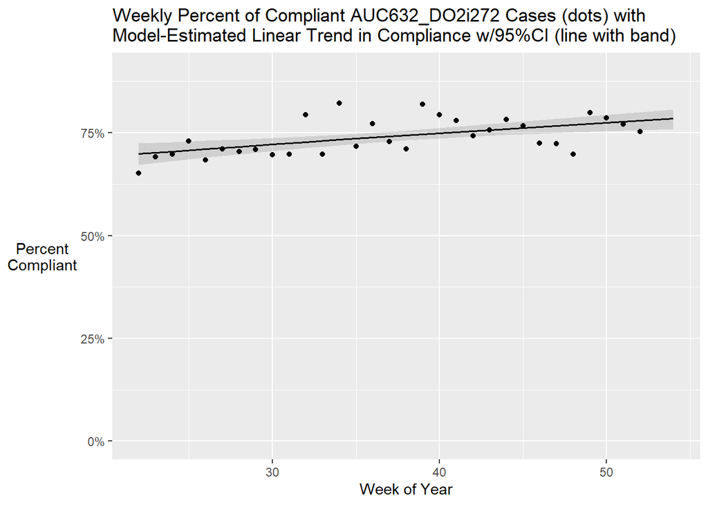

```r
mp2 +
  geom_point(data  = compliantByWeek, aes(x=week, y = PointEst))   +
  scale_y_continuous(labels = scales::percent, limits = c(0,.9))  +
  scale_x_continuous(breaks = c(0,10,20,30,40,50))  +
  ggtitle("Weekly Percent of Compliant AUC632_DO2i272 Cases (dots) with\nModel-Estimated Linear Trend in Compliance w/95%CI (line with band)") +
  xlab("Week of Year") +
  ylab("Percent\nCompliant") +
  theme(axis.title.y = element_text(angle = 0, vjust = .5))
```

## Interpretation

We analyzed 30,101 DO2i observations from 5,325 cases reporting at least one DO2i observation per case among non-reopeartive CABGs between 2022-06-01 and 2022-12-31. The median number of observations per case was 5, the mean was 5.6506476, with a standard deviation of 3.3429817. There was no trend over the study period in the number of Do2i observations collected per case. Compliance to DO2i practice guidelines was defined as a DO2i of 272 or greater. Binary logistic regression models were estimated to quantify the magnitude and statistical uncertainty of the apparent upward trend in probability of compliance over the study period in individual DO2i readings as well as area under the curve, using the threshold of 272 and an overall AUC of 632. Time was operationalized as the week of year in which a case and it’s accompanying observations was completed, between 22 and 52. Results from this model indicate a statistically significant linear increase in the log odds/predicted probability of compliance to the 272 threshold (p<0.001). A similar analysis of AUC compliance was carried out on 5,292 cases with at least two DO2i readings over the same time period. Logistic regression analysis showed a statistically reliable positive trend over the study period in the probability of compliance to an AUC of 632 (p<0.001).